# Analysis for CHI 2025 submission.

# Effects Plots

Here, you should manually set `model.to.plot` as the model for which you want to generate effects plots.

```r
model.to.plot <- combo.model
```

```
Error: object 'combo.model' not found
```

## CHI 2025

Since we have different predictors for this analysis, we need different effects plots.

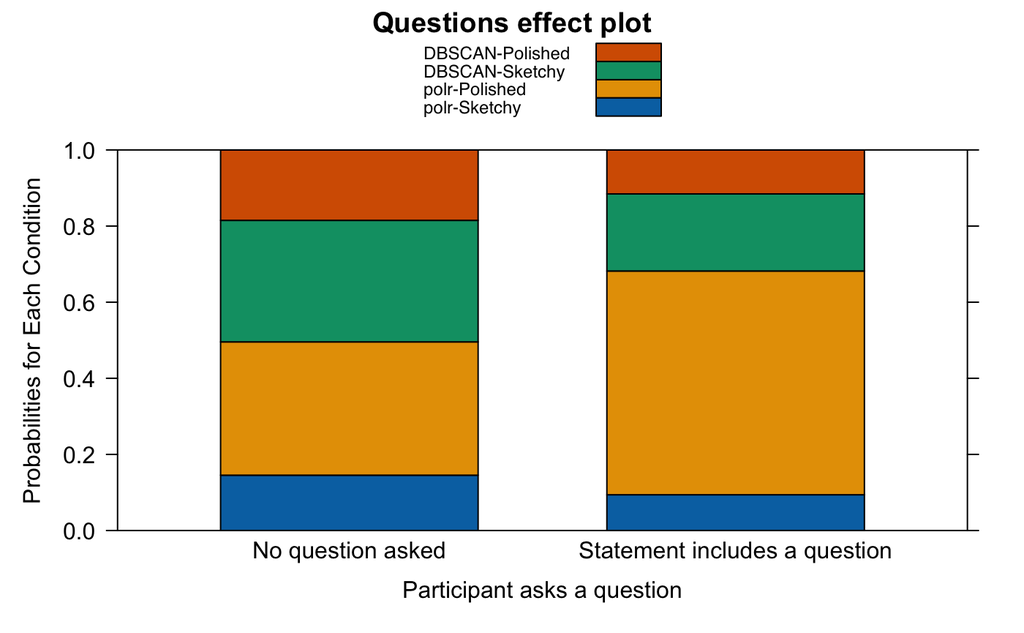

```r
model.to.plot <- model.recode

eff.to.plot <- allEffects(model.to.plot)
plot(eff.to.plot, 'Questions', rug=FALSE, style="stacked", xlab="Participant asks a question", ylab="Probabilities for Each Condition")
```

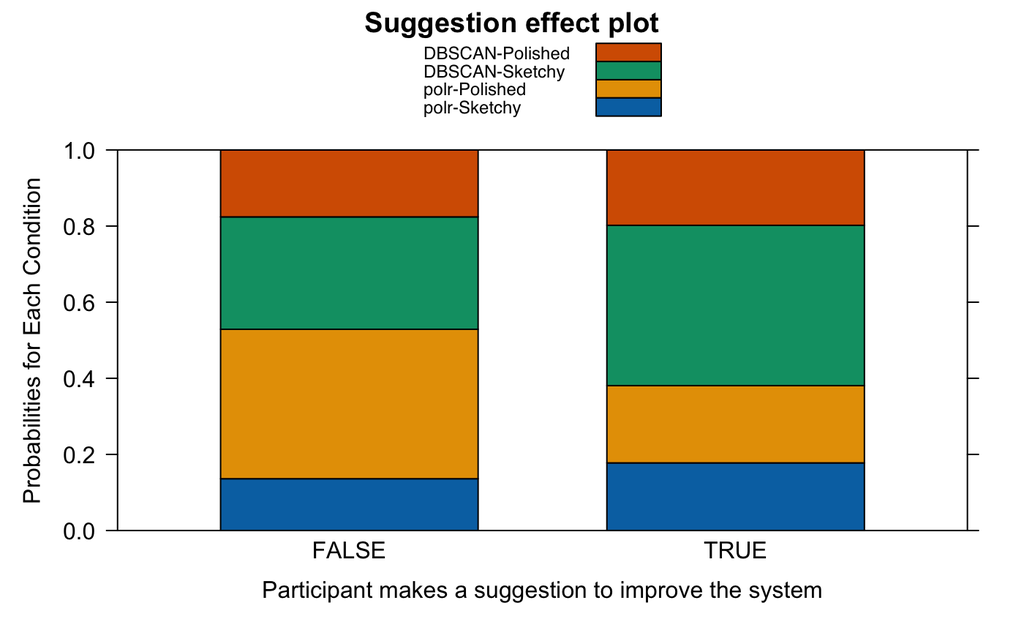

```r
plot(eff.to.plot, 'Suggestion', rug=FALSE, style="stacked", xlab="Participant makes a suggestion to improve the system", ylab="Probabilities for Each Condition")
```

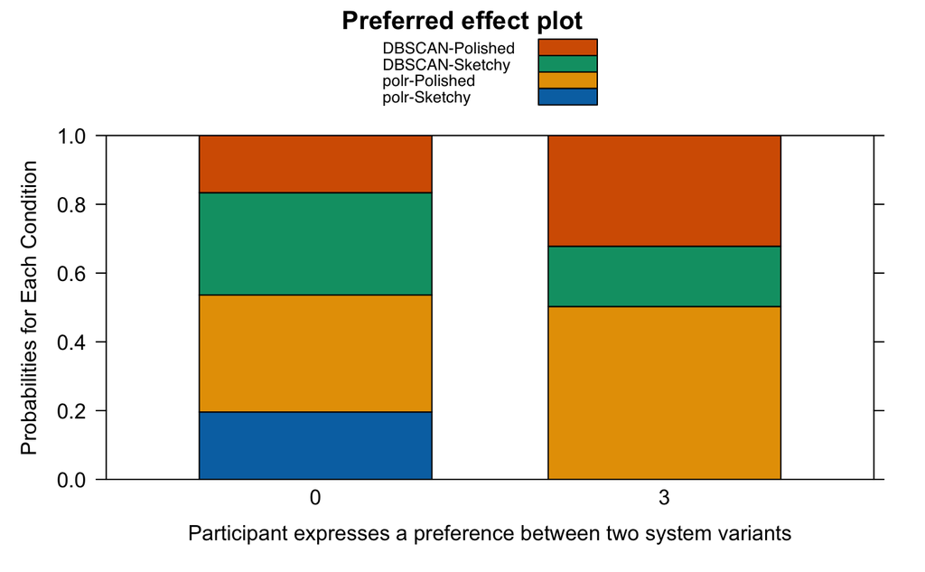

```r
plot(eff.to.plot, 'Preferred', rug=FALSE, style="stacked", xlab="Participant expresses a preference between two system variants", ylab="Probabilities for Each Condition")
```

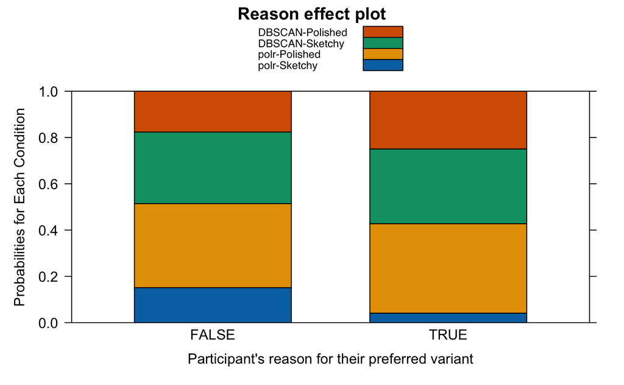

```r
plot(eff.to.plot, 'Reason', rug=FALSE, style="stacked", xlab="Participant's reason for their preferred variant", ylab="Probabilities for Each Condition")
```

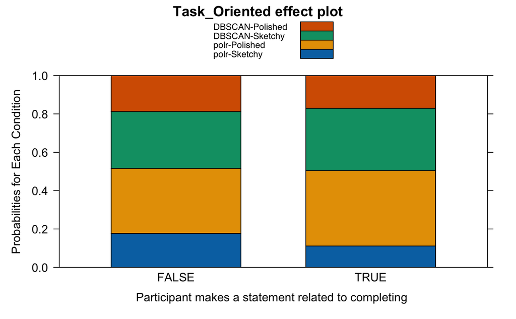

```r
plot(eff.to.plot, 'Task_Oriented', rug=FALSE, style="stacked", xlab="Participant makes a statement related to completing ", ylab="Probabilities for Each Condition")
```

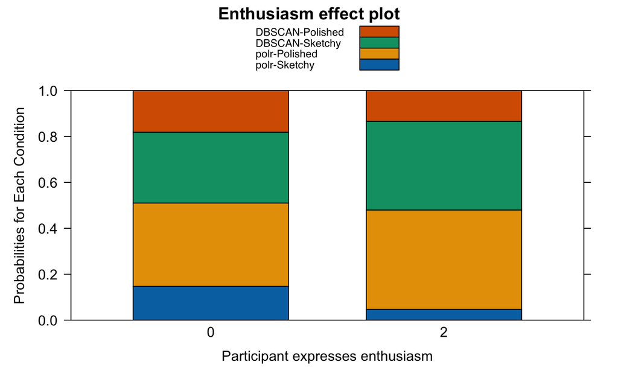

```r
plot(eff.to.plot, 'Enthusiasm', rug=FALSE, style="stacked", xlab="Participant expresses enthusiasm", ylab="Probabilities for Each Condition")
```

# Chi-squared

Messing around with this again… but for now just ignore this blokc.

```r
# create the contingency table
cont.table <- table(outvis.recode$Suggestion, outvis.recode$Model, outvis.recode$Viz)
cont.table
```

```
, ,  = Polished


        DBSCAN polr
  FALSE     95  214
  TRUE      14   12

, ,  = Sketchy


        DBSCAN polr
  FALSE    159  102
  TRUE      28   25
```

```r
# run the overal CMH test
mantelhaen.test(cont.table)
```

```
    Mantel-Haenszel chi-squared test with continuity correction

data:  cont.table
Mantel-Haenszel X-squared = 0.13691, df = 1, p-value = 0.7114
alternative hypothesis: true common odds ratio is not equal to 1
95 percent confidence interval:
 0.5536169 1.4321395
sample estimates:
common odds ratio
         0.890425
```

```r
# make sure there's no three-way association present
woolf_test(cont.table)
```

```
    Woolf-test on Homogeneity of Odds Ratios (no 3-Way assoc.)

data:  cont.table
X-squared = 6.4249, df = 1, p-value = 0.01125
```

```r
# conduct post-hoc test (only really applicable if/when initial CMH test is significant)
groupwiseCMH(cont.table, fisher=FALSE, chisq=TRUE)
```

| Group | Test | p.value | adj.p |
| --- | --- | --- | --- |
| Polished | Chi.square | 0.028 | 0.056 |
| Sketchy | Chi.square | 0.347 | 0.347 |

# Code-wise Logistic Regression

What if we set up a separate model for each of our codes of interest, predicted by the two (interacting) condition variables?

Since we’re running multiple separate models to test a “family” of hypotheses on the same data set, we’ll need to perform some correction for multiple comparisons. Here, we’ll use the [Benjamini-Hochberg procedure](https://en.wikipedia.org/wiki/False_discovery_rate#Benjamini%E2%80%93Hochberg_procedure).

## Question

```r
mod.Question <- glm(outvis.recode$Question ~ outvis.recode$Model * outvis.recode$Viz, family="binomial")
# compare against the null model
null.Question <- glm(outvis.recode$Question ~ 1, family="binomial")
anova(null.Question, mod.Question, test = "Chisq")
```

```
Analysis of Deviance Table

Model 1: outvis.recode$Question ~ 1
Model 2: outvis.recode$Question ~ outvis.recode$Model * outvis.recode$Viz
  Resid. Df Resid. Dev Df Deviance Pr(>Chi)
1       648     332.16
2       645     323.60  3   8.5684  0.03562 *
---
Signif. codes:  0 ‘***’ 0.001 ‘**’ 0.01 ‘*’ 0.05 ‘.’ 0.1 ‘ ’ 1
```

## Suggestion

```r
mod.Suggestion <- glm(outvis.recode$Suggestion ~ outvis.recode$Model * outvis.recode$Viz, family="binomial")
# compare against the null model
null.Suggestion <- glm(outvis.recode$Suggestion ~ 1, family="binomial")
anova(null.Suggestion, mod.Suggestion, test = "Chisq")
```

```
Analysis of Deviance Table

Model 1: outvis.recode$Suggestion ~ 1
Model 2: outvis.recode$Suggestion ~ outvis.recode$Model * outvis.recode$Viz
  Resid. Df Resid. Dev Df Deviance Pr(>Chi)
1       648     480.71
2       645     461.29  3   19.419 0.000224 ***
---
Signif. codes:  0 ‘***’ 0.001 ‘**’ 0.01 ‘*’ 0.05 ‘.’ 0.1 ‘ ’ 1
```

## Preferred

```r
mod.Preferred <- glm(outvis.recode$Preferred ~ outvis.recode$Model * outvis.recode$Viz, family="binomial")
# compare against the null model
null.Preferred <- glm(outvis.recode$Preferred ~ 1, family="binomial")
anova(null.Preferred, mod.Preferred, test = "Chisq")
```

```
Analysis of Deviance Table

Model 1: outvis.recode$Preferred ~ 1
Model 2: outvis.recode$Preferred ~ outvis.recode$Model * outvis.recode$Viz
  Resid. Df Resid. Dev Df Deviance Pr(>Chi)
1       648     171.62
2       645     158.38  3   13.236 0.004152 **
---
Signif. codes:  0 ‘***’ 0.001 ‘**’ 0.01 ‘*’ 0.05 ‘.’ 0.1 ‘ ’ 1
```

## Reason

```r
mod.Reason <- glm(outvis.recode$Reason ~ outvis.recode$Model * outvis.recode$Viz, family="binomial")
# compare against the null model
null.Reason <- glm(outvis.recode$Reason ~ 1, family="binomial")
anova(null.Reason, mod.Reason, test = "Chisq")
```

```
Analysis of Deviance Table

Model 1: outvis.recode$Reason ~ 1
Model 2: outvis.recode$Reason ~ outvis.recode$Model * outvis.recode$Viz
  Resid. Df Resid. Dev Df Deviance Pr(>Chi)
1       648     266.72
2       645     259.05  3   7.6705  0.05333 .
---
Signif. codes:  0 ‘***’ 0.001 ‘**’ 0.01 ‘*’ 0.05 ‘.’ 0.1 ‘ ’ 1
```

## Task-Oriented

```r
mod.Task <- glm(outvis.recode$Task_Oriented ~ outvis.recode$Model * outvis.recode$Viz, family="binomial")
# compare against the null model
null.Task <- glm(outvis.recode$Task_Oriented ~ 1, family="binomial")
anova(null.Task, mod.Task, test = "Chisq")
```

```
Analysis of Deviance Table

Model 1: outvis.recode$Task_Oriented ~ 1
Model 2: outvis.recode$Task_Oriented ~ outvis.recode$Model * outvis.recode$Viz
  Resid. Df Resid. Dev Df Deviance Pr(>Chi)
1       648     899.26
2       645     894.98  3   4.2778    0.233
```

## Enthusiasm

```r
mod.Enthusiasm <- glm(outvis.recode$Enthusiasm ~ outvis.recode$Model * outvis.recode$Viz, family="binomial")
# compare against the null model
null.Enthusiasm <- glm(outvis.recode$Enthusiasm ~ 1, family="binomial")
anova(null.Enthusiasm, mod.Enthusiasm, test = "Chisq")
```

```
Analysis of Deviance Table

Model 1: outvis.recode$Enthusiasm ~ 1
Model 2: outvis.recode$Enthusiasm ~ outvis.recode$Model * outvis.recode$Viz
  Resid. Df Resid. Dev Df Deviance Pr(>Chi)
1       648     192.16
2       645     189.78  3   2.3775   0.4978
```

## Interpretation

After the BH correction, only two of these models/codes are significant: for Suggestion and for Preferred.

```r
summary(mod.Suggestion)
```

```
Call:
glm(formula = outvis.recode$Suggestion ~ outvis.recode$Model *
    outvis.recode$Viz, family = "binomial")

Deviance Residuals:
    Min       1Q   Median       3Q      Max
-0.6621  -0.5696  -0.5243  -0.3303   2.4231

Coefficients:
                                                 Estimate Std. Error z value Pr(>|z|)
(Intercept)                                       -1.9148     0.2863  -6.689 2.25e-11 ***
outvis.recode$Modelpolr                           -0.9662     0.4123  -2.344   0.0191 *
outvis.recode$VizSketchy                           0.1781     0.3521   0.506   0.6129
outvis.recode$Modelpolr:outvis.recode$VizSketchy   1.2969     0.5116   2.535   0.0113 *
---
Signif. codes:  0 ‘***’ 0.001 ‘**’ 0.01 ‘*’ 0.05 ‘.’ 0.1 ‘ ’ 1

(Dispersion parameter for binomial family taken to be 1)

    Null deviance: 480.71  on 648  degrees of freedom
Residual deviance: 461.29  on 645  degrees of freedom
AIC: 469.29

Number of Fisher Scoring iterations: 5
```

Participants were less likely to make suggestions with the polr model, but they were more likely to make suggestions when the polr model was presented using the Sketchy rendering style. Infact, that interaction effect outweiged the main effect of the polr model.

```r
summary(mod.Preferred)
```

```
Call:
glm(formula = outvis.recode$Preferred ~ outvis.recode$Model *
    outvis.recode$Viz, family = "binomial")

Deviance Residuals:
    Min       1Q   Median       3Q      Max
-0.3644  -0.2851  -0.1799  -0.1799   2.8749

Coefficients:
                                                 Estimate Std. Error z value Pr(>|z|)
(Intercept)                                       -2.6791     0.3907  -6.857 7.04e-12 ***
outvis.recode$Modelpolr                           -0.5036     0.5181  -0.972   0.3310
outvis.recode$VizSketchy                          -1.4373     0.7010  -2.050   0.0403 *
outvis.recode$Modelpolr:outvis.recode$VizSketchy -14.9461   954.2647  -0.016   0.9875
---
Signif. codes:  0 ‘***’ 0.001 ‘**’ 0.01 ‘*’ 0.05 ‘.’ 0.1 ‘ ’ 1

(Dispersion parameter for binomial family taken to be 1)

    Null deviance: 171.62  on 648  degrees of freedom
Residual deviance: 158.38  on 645  degrees of freedom
AIC: 166.38

Number of Fisher Scoring iterations: 18
```